# Mini-Project 2

Jessica Jacinto and Anna Ballou

2019-03-24

Link to github repository:

```r
library(tidyverse)
library(ggplot2)
library(ggthemes)
load("house_elections.rda")
load("candidates.rda")
load("committees.rda")
load("contributions.rda")
```

## Data Wrangling

First we selected the variables state and party from the house elections table because they were relevant to our investigation. Then further filtered through to only give us the states in the midwest to make a more focused data set.

```r
elections_table <- house_elections %>%
  select(state, party) %>%
  filter(state == "IL" | state == "IN" | state == "IA" | state == "KS" | state == "MI" | state == "MN" | state == "MO" | state == "NE" | state == "ND" | state == "OH" | state == "SD" | state == "WI")
```

Next we selected the variables state and transaction_amt from the contributions table because they were relevant to our investigation. We filtered to find all transactions amounts greater than zero as we only wanted to examine cases where actual transactions were made and not a return or any other off amount that would skew our data.

```r
contributions_table <- contributions %>%
  select(state, transaction_amt) %>%
  filter(transaction_amt > 0)
```

Lastly, we took the two tables above and joined them together by the state variable that they both have. Then we grouped by state and calculated the average transaction amount for each state by using a summarize funtion. We arranged the table from greatest average transaction to least.

```r
final_table <- elections_table %>%
  inner_join(contributions_table, by = c("state")) %>%
  group_by(state) %>%
  summarize(avg_transaction = mean(transaction_amt)) %>%
  arrange(desc(avg_transaction))
print(final_table)
```

```
## # A tibble: 12 x 2
##    state avg_transaction
##    <chr>           <dbl>
##  1 IL              3368.
##  2 ND              2801.
##  3 IA              2343.
##  4 IN              2282.
##  5 NE              1969.
##  6 MO              1890.
##  7 MI              1889.
##  8 SD              1691.
##  9 KS              1559.
## 10 WI              1228.
## 11 OH               936.
## 12 MN               928.
```

## Data Graphic

We plotted state (specifically in the midwest) as the x against the average transaction amount for that state as the y. We did this using a bar graph.

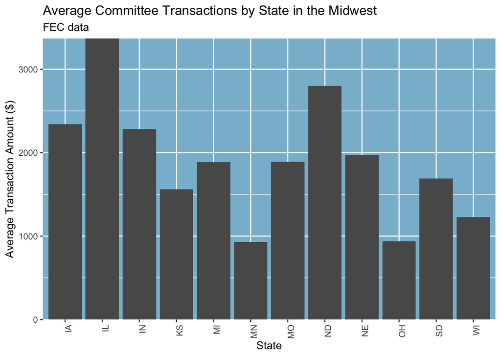

```r
state_graph <- ggplot(data = final_table, aes(x=state, y=avg_transaction)) +
  geom_bar(mapping = NULL, data = NULL, stat = "identity") +
  scale_y_continuous("Average Transaction Amount ($)", expand=c(0,0)) +
  scale_x_discrete("State") +
  theme(axis.text.x = element_text(angle = 90, hjust = 1)) +
  ggtitle("Average Committee Transactions by State in the Midwest",
          subtitle = "FEC data") +
  theme(panel.background = element_rect(
    fill = "#89BBD4"))

print(state_graph)
```

## Data Explanation

Higher values of avgerage transaction indicates that a state’s committees designate greater amounts of money to politics. Including transaction types from spending against a candidate to loans, a higher average indicates that a state assigned more monetary value to its political climate.

## Room For Improvement

The data graphic shows us the average transaction amount that is spent in each state in the midwest currently. This is some fairly broad information because we don’t know where that money is going and what the money is for. It would be interesting to see the amounts that go to certain parties in specific states. Then to further that see how much it is in opposition or in approval or for that party. It would also be nice to dig deeper and see how the money actually effected the climate. Did larger amounts yield a large result or do things stay as they usually are. It would be fairly difficult but even getting other years and seeing a comparison could give a better understanding of relationship between money, votes, and the winner at the end of the day.

## function

```r
#list of individual states
midwest = c("IL", "IN", "IA", "KS", "MI", "MN", "MO", "NE", "ND", "OH", "SD", "WI")
south = c("DE", "FL", "GA", "NC", "SC", "VA", "WV", "MD", "AL", "KY", "MI", "TN", "AK", "LA", "OK", "TX")
northeast = c("CT", "ME", "MA", "NH", "RI", "VT", "NJ", "NY", "PA")
west = c("AZ", "CO", "ID", "MT", "NV", "NM", "UT", "WY", "AL", "CA", "HI", "OR", "WA")
```

```r
state_list <- function(state_arg){
  elections_individual <- house_elections %>%
  select(state, party) %>%
  filter(state == state_arg)

  contributions_individual <- contributions %>%
  select(state, transaction_amt) %>%
  filter(transaction_amt > 0) %>%
  filter(state == state_arg)


  final_individual <- elections_individual %>%
  inner_join(contributions_individual, by = c("state")) %>%
  group_by(state) %>%
  summarize(avg_transaction = mean(transaction_amt)) %>%
  print(final_individual)

}

state_list(west)
```

```
## # A tibble: 13 x 2
##    state avg_transaction
##    <chr>           <dbl>
##  1 AL              1761.
##  2 AZ              2942.
##  3 CA              3267.
##  4 CO              2145.
##  5 HI              2896.
##  6 ID              1795.
##  7 MT              3559.
##  8 NM               552.
##  9 NV              2326.
## 10 OR              2238.
## 11 UT              4583.
## 12 WA              1896.
## 13 WY              2033.
```

```r
state_list(northeast)
```

```
## # A tibble: 7 x 2
##   state avg_transaction
##   <chr>           <dbl>
## 1 CT              2862.
## 2 MA              4640.
## 3 ME              2790.
## 4 NJ              2429.
## 5 NY              2549.
## 6 PA              1919.
## 7 RI              1777.
```

```r
state_list(midwest)
```

```
## # A tibble: 11 x 2
##    state avg_transaction
##    <chr>           <dbl>
##  1 IA              2112.
##  2 IL              4950.
##  3 IN              4306.
##  4 KS              1575.
##  5 MI              1852.
##  6 MN               949.
##  7 MO              2062.
##  8 NE              2214.
##  9 OH               884.
## 10 SD              1637.
## 11 WI              1241.
```

```r
state_list(south)
```

```
## # A tibble: 13 x 2
##    state avg_transaction
##    <chr>           <dbl>
##  1 AL              1932.
##  2 FL              2634.
##  3 GA              2425.
##  4 KY              1747.
##  5 LA              1636.
##  6 MD             47248.
##  7 MI              2079.
##  8 NC              1546.
##  9 OK              1943.
## 10 SC              3792.
## 11 TN              1707.
## 12 TX              2335.
## 13 VA             22076.
```

https://github.com/Jessica-Jacinto/sds192-mp2.git

https://ballotpedia.org/North_Dakota_House_of_Representatives_elections,_2014

https://en.wikipedia.org/wiki/2014_Minnesota_House_of_Representatives_election

https://www.minnpost.com/state-government/2018/09/how-minnesotas-major-independent-expenditure-committees-have-been-spending-their-money-on-the-2018-election/